# Lipidomics Data Input and Clean

Chenghao Zhu

2018-07-09

# 1 Introduction

Metabolomics are powerful experiment approaches that analyzes all, or a specific class, of small molecule compounds in a biological specimen. Lipidomics is a special case of Metabolomics that only focus on the lipids. Metabolomics and lipidomics are now being adopted many different type of studies with different purposes, as a tool to answer different scientific questions. Metabolomics and lipidomics often generates big data with feature numbers very from hundreds to thousands. The package *Metabase* aims to help researchers handle, analyze and visualize metabolomics and lipidomics data. This vignettes is a workflow of how import and process the lipidomics data reported by the [West Coast Metabolomics Center, CA](http://metabolomics.ucdavis.edu/).

# 2 Install Metabase

The Metabase package can be installed from github

```r
devtools::install_github("zhuchcn/Metabase")
```

# 3 Data

The data used in this vignette is a lipidomics experiment from a cross-over nutritional intervention study. 10 subjects were given 2 dietary treatment, and blood samples were taken before and after each treatment.

Data can be downloaed from here.

```r
data.raw = "https://raw.githubusercontent.com/zhuchcn/Metabase/master/data-raw/302870_Zhu_CSH-QTOF_lipidomics.xlsx"
standards = "https://raw.githubusercontent.com/zhuchcn/Metabase/master/data-raw/wcmc_lipidomics_standards.csv"
download.file(url = data.raw,  destfile = "")
download.file(url = standards, destfile = "wcmc_lipidomics_standards.csv")
```

# 4 Data import

## 4.1 Read data

Arguments: + **file:** File path to the excel spreadsheet. +** sheet:** The sheet name with data. + **conc_range:** The cell range for concentration data. + **sample_range:** The cell range for sample data. + **feature_range:** The cell range for feature data. + **InChIKey:** The name of the column with InChI Key. The InChI Key is neccesary for later process and analysis.

```r
library(Metabase)
file = "302870_Zhu_CSH-QTOF_lipidomics.xlsx"
mset = import_wcmc_excel(
    file            = file,
    sheet           = "Submit",
    conc_range      = "I10:BA613",
    sample_range    = "H1:BA9",
    feature_range   = "A9:H613",
    InChIKey        = "InChI Key",
    experiment_type = "Lipidomics"
)
mset
```

```
##              >>>>>> Metabolomics Experiment <<<<<<
## conc_table():           [  45 samples  and 604 features          ]
## sample_table():         [  45 samples  and   8 sample  variables ]
## feature_data():         [ 604 features and   8 feature variables ]
## experiment_data():      [   9 experiment attributes              ]
```

```r
cat("Number of features:", nfeatures(mset),
    "\nNumber of samples: ", nsamples(mset))
## Number of features: 604
## Number of samples:  45
```

## 4.2 Remove features

The dataset has 604 features. However 364 of them are unknow.

```r
cat("Annotated:", sum(!is.na(feature_data(mset)$InChIKey)),
    "\nUnknown:  ", sum(is.na(feature_data(mset)$InChIKey)))
## Annotated: 240
## Unknown:   364
```

The unknown features can be removed using the subset_features function

```r
mset = subset_features(mset, !is.na(feature_data(mset)$InChIKey))
```

## 4.3 Collapse QC samples

The first 5 samples are quality control samples.

```r
head(sample_table(mset), 8)
```

```
##           Sample # Species  Organ Treatment Timepoint Subject
## Biorec001       QC   Human Plasma      <NA>      <NA>    <NA>
## Biorec002       QC   Human Plasma      <NA>      <NA>    <NA>
## Biorec003       QC   Human Plasma      <NA>      <NA>    <NA>
## Biorec004       QC   Human Plasma      <NA>      <NA>    <NA>
## Biorec005       QC   Human Plasma      <NA>      <NA>    <NA>
## MD101A           1   Human Plasma       EXP       Pre     101
## MD101B           2   Human Plasma       EXP      Post     101
## MD101C           3   Human Plasma       CTL       Pre     101
##                                 File ID          RT
## Biorec001  Biorec001_posCSH_preZhu001.d Peak Height
## Biorec002 Biorec002_posCSH_postZhu010.d Peak Height
## Biorec003 Biorec003_posCSH_postZhu020.d Peak Height
## Biorec004 Biorec004_posCSH_postZhu030.d Peak Height
## Biorec005 Biorec005_posCSH_postZhu040.d Peak Height
## MD101A    Zhu027_posCSH_FFS-107-A_001.d Peak Height
## MD101B    Zhu008_posCSH_FFS-107-B_002.d Peak Height
## MD101C    Zhu040_posCSH_FFS-107-C_003.d Peak Height
```

```r
mset = collapse_QC(mset, qc_names = paste0("Biorec00", 1:5))
mset
```

```
##              >>>>>> Metabolomics Experiment <<<<<<
## conc_table():           [  40 samples  and 240 features          ]
## sample_table():         [  40 samples  and   8 sample  variables ]
## feature_data():         [ 240 features and  11 feature variables ]
## experiment_data():      [   9 experiment attributes              ]
```

## 4.4 Filling NAs

To see the missing values in the dataset, we can call the plot_hist_NA function. In this dataset, there are 3 features have 2 missing values, and 1 with 12.

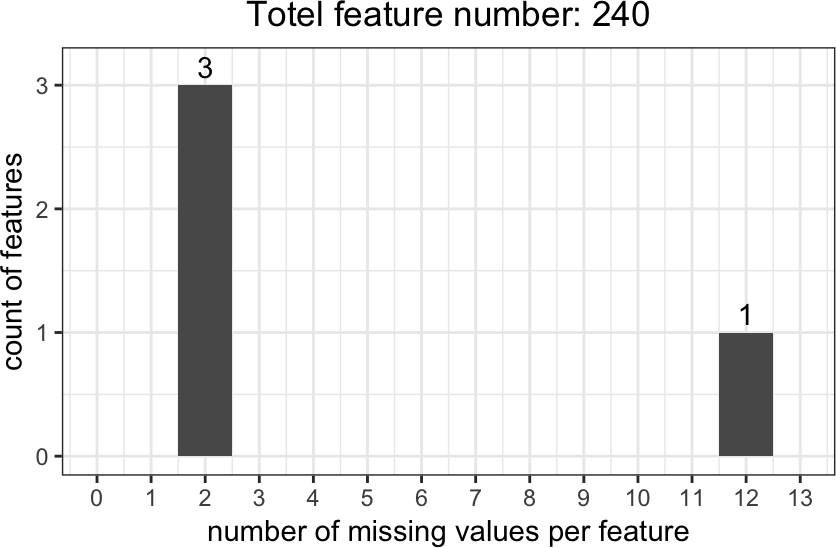

```r
plot_hist_NA(mset)
```

We can remove features with too many missing values using subset_features. The call below will keep all features that have less than 5 missing values.

```r
mset = subset_features(
    mset, apply(conc_table(mset), 1, function(x) sum(is.na(x)) < 5) )
```

Then we can fill up the rest NAs using half of the lowest value of this feature in all samples.

```r
mset = transform_by_feature(
    mset, function(x) ifelse(is.na(x), min(x, na.rm = TRUE)/2, x)
)
```

## 4.5 Calculate concentration using internal standards

```r
internal_standards = read.csv("wcmc_lipidomics_standards.csv")
head(internal_standards)
```

```
##                               standard                    InChIKey
## 1 22:1 Cholesterol Ester (Add to MTBE) SQHUGNAFKZZXOT-JWTURFAQSA-N
## 2                       PE (17:0/17:0) YSFFAUPDXKTJMR-DIPNUNPCSA-N
## 3                       PG (17:0/17:0) ZBVHXVKEMAIWQQ-QPPIDDCLSA-N
## 4                        PC (17:0/0:0) SRRQPVVYXBTRQK-XMMPIXPASA-N
## 5                      C17 Sphingosine RBEJCQPPFCKTRZ-LHMZYYNSSA-N
## 6                         C17 Ceramide ICWGMOFDULMCFL-QKSCFGQVSA-N
##         class   spike_amt spike_unit
## 1          CE 16.36363636         ug
## 2          PE  0.36818182         ug
## 3          PG  1.47272727         ug
## 4         LPC  0.24545454         ug
## 5 Sphingosine  0.05454545         ug
## 6         Cer  0.12272727         ug
```

Before the features can be calibrated to the internal standards, we need to first assign the lipid calss to each annotated feature. The function *assign_lipid_class* takes the annotation name and assign a lipid class to it. We also need to specify the ESI mode.

```r
feature_data(mset)$class = assign_lipid_class(feature_data(mset)$Annotation)
feature_data(mset)$ESI = ifelse(grepl("\\+$", feature_data(mset)$Species),
                                "pos", "neg")
```

Next, the internal standard data can be addded to the experiment_data slot of the data object.

```r
experiment_data(mset)$institute = "West Coast Metabolomics Center"
experiment_data(mset)$sample_volumn_ul = 20
experiment_data(mset)$internal_standards = internal_standards
experiment_data(mset)
```

```
##           >>>>>> Lipidomics Experiment Data <<<<<<
##
## Institute: West Coast Metabolomics Center
## Experiment Type: lipidomics
## Sample Volumn Ul: 20
## Internal Standards: a 16 by 5 data frame
```

Then the features can be calibrated.

```r
mset = calibrate_lipidomics_wcmc(mset, cid = "InChIKey",
                                 class = "class", ESI = "ESI")
mset
```

```
##              >>>>>> Metabolomics Experiment <<<<<<
## conc_table():           [  40 samples  and 215 features          ]
## sample_table():         [  40 samples  and   8 sample  variables ]
## feature_data():         [ 215 features and  13 feature variables ]
## experiment_data():      [   9 experiment attributes              ]
```

## 4.6 Filter by CV

The last problem is, some features are detected under both positive and negative ESI mode. This could be problomatic for example for some multi-variable analysis. We can only keep whichever with a lower CV.

```r
mset = filter_by_cv(mset, cv = "qc_cv", cid = "InChIKey")
mset
```

```
##              >>>>>> Metabolomics Experiment <<<<<<
## conc_table():           [  40 samples  and 170 features          ]
## sample_table():         [  40 samples  and   8 sample  variables ]
## feature_data():         [ 170 features and  14 feature variables ]
## experiment_data():      [   9 experiment attributes              ]
```

The data now is cleaned up and is ready for any statistic analysis and visualization. You can see the quality of the test as below.

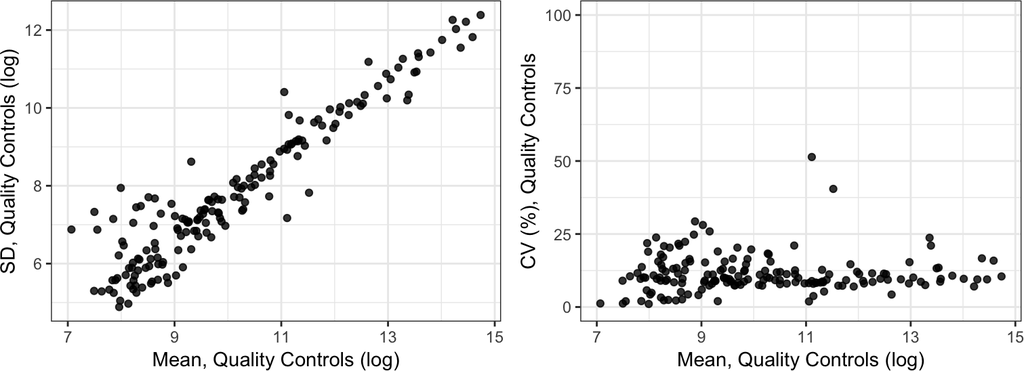

```r
plot_qc(mset, mean = "qc_mean", sd = "qc_sd", cv = "qc_cv")
```